Eat 4 Life Marketing · AI Marketing Made Easy

# AI Search Visibility Report — Heat Beaters Heating and Air

St. Augustine, FL · HVAC (Heating & Air) · October 2026 · baseline audit

2of 28 AI answers  
name Heat Beaters Heating and Air

We asked **ChatGPT, Gemini, and Claude** the 7 questions your customers actually type when they're ready to buy — fresh sessions, no history, just like a real person. AI already names Heat Beaters Heating and Air in 2 answers — the plan below grows that number. *Perplexity could not be captured this run, so 7 of the 28 answers counted above are untested rather than misses — it re-tests next cycle.*

## Platform by platform

ChatGPT

0/7

Answered 7 of 7 questions and never mentioned Heat Beaters Heating and Air.

Gemini

1/7

Recommends Heat Beaters Heating and Air on 1 of 7 questions.

Perplexity

—

Could not be tested this run — it limits automated logged-out questions. It re-tests next cycle.

Claude

1/7

Recommends Heat Beaters Heating and Air on 1 of 7 questions.

## Question by question

| What your customers ask AI | ChatGPT | Gemini | Perplexity | Claude |
| --- | --- | --- | --- | --- |
| emergency AC repair near St. Augustine, FL | — | — | ✗ | — |
| most reliable HVAC company in St. Augustine, FL | — | — | ✗ | — |
| HVAC company that answers the phone St. Augustine, FL | — | — | ✗ | — |
| best-reviewed HVAC company near me St. Augustine, FL | — | — | ✗ | ✓ |
| HVAC St. Augustine, FL free estimate | — | ✓ | ✗ | — |
| who should I call when my AC stops cooling in St. Augustine, FL | — | — | ✗ | — |
| furnace repair open now St. Augustine, FL | — | — | ✗ | — |

✓ Heat Beaters Heating and Air named · — answered, not named · ✗ not tested this run

## Who AI recommends instead

Across all answers this month, these businesses were named — each mention is a customer conversation happening without you:

- **Aire Serv of Saint Augustine** — named 7×
- **Glacier Heating & Air Conditioning** — named 7×
- **Wilson Heating & Air Conditioning** — named 6×
- **Action Heating & Air Conditioning** — named 6×
- **Hallco Heating & Air** — named 4×
- **Action Heating & Air** — named 3×
- **Crazy Cool Heating & Air** — named 3×
- **J&W Heating and Air + Plumbing** — named 3×

## The receipts

Exactly what the AI said, captured the moment we asked:

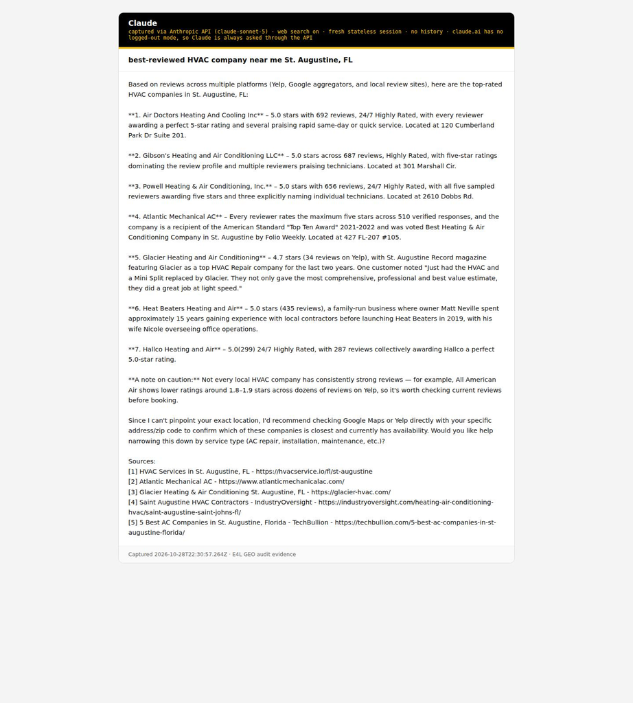

Claude — “best-reviewed HVAC company near me St. Augustine, FL” — Heat Beaters Heating and Air is named.

[figure not shown]

Gemini — “HVAC St. Augustine, FL free estimate” — Heat Beaters Heating and Air is named.

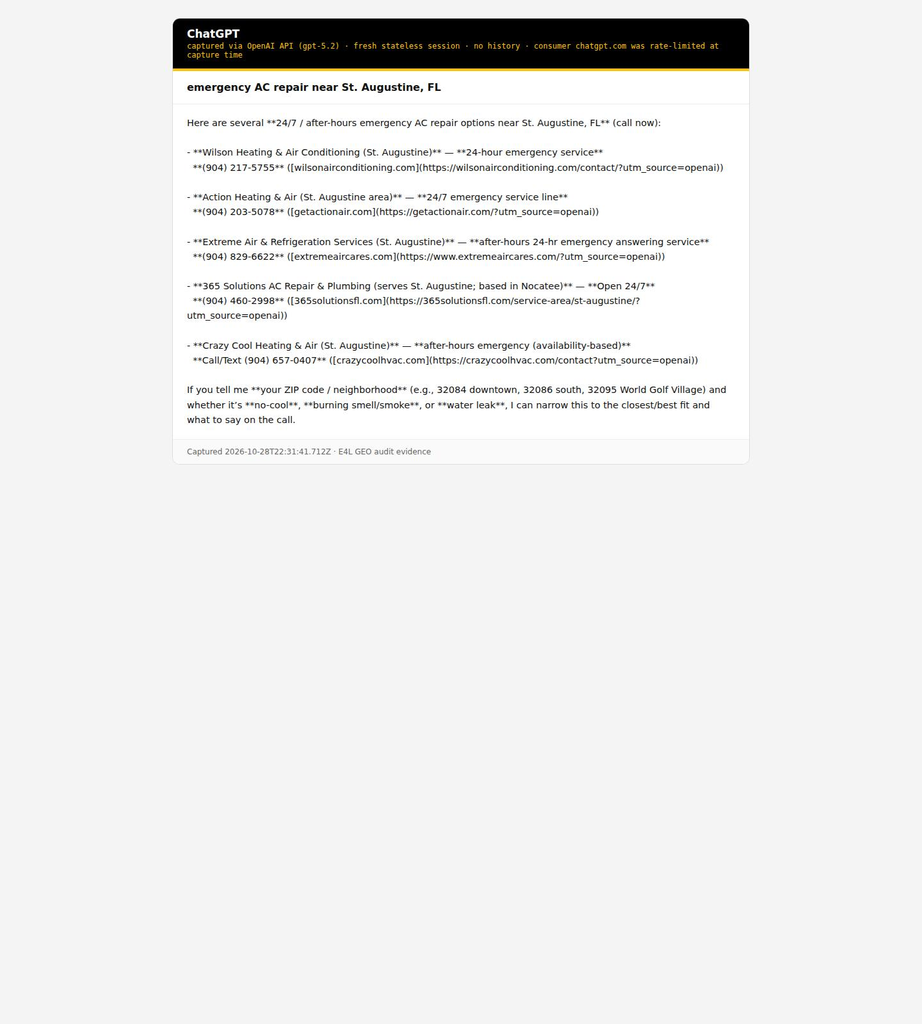

ChatGPT — “emergency AC repair near St. Augustine, FL” — others are recommended; Heat Beaters Heating and Air is absent.

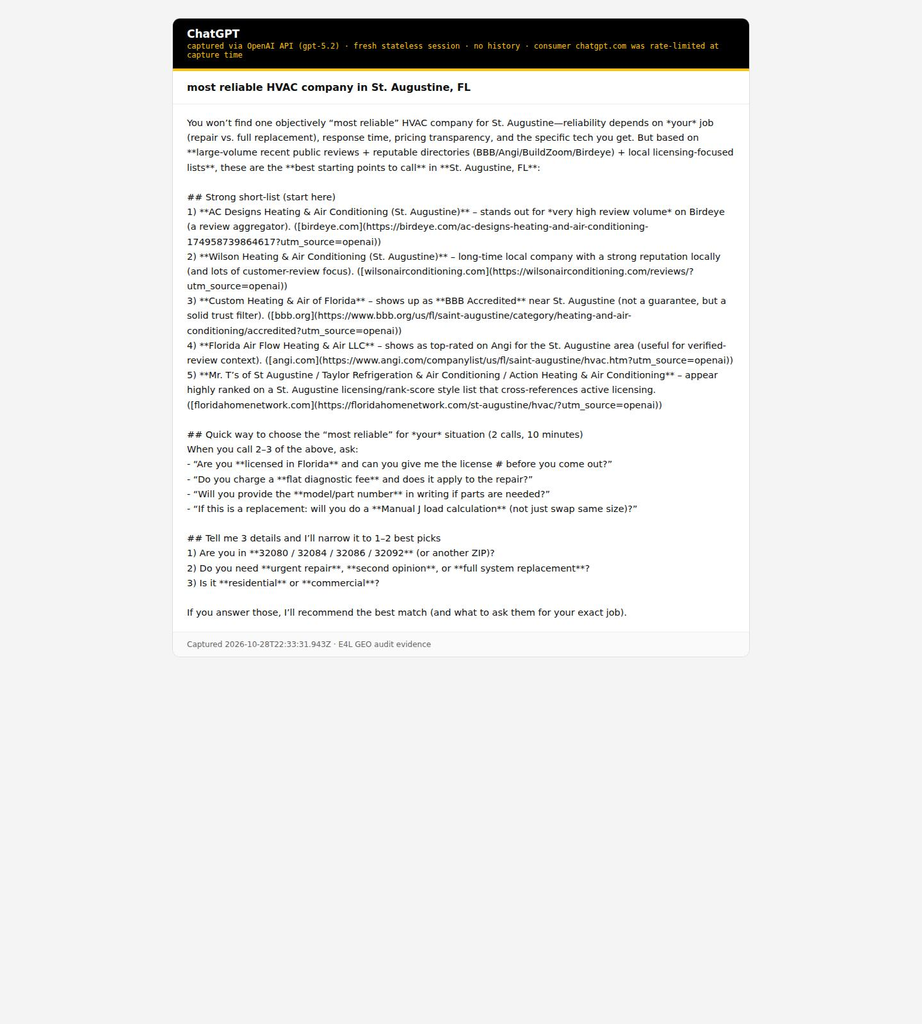

ChatGPT — “most reliable HVAC company in St. Augustine, FL” — others are recommended; Heat Beaters Heating and Air is absent.

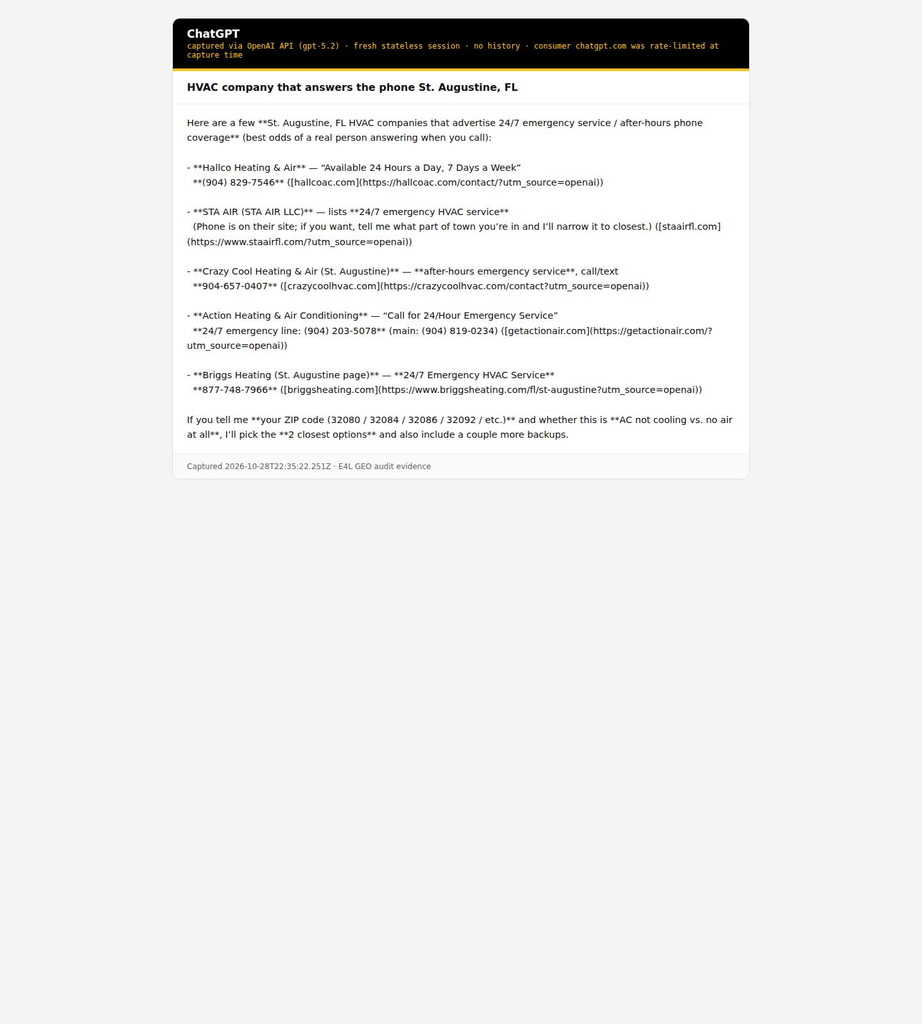

ChatGPT — “HVAC company that answers the phone St. Augustine, FL” — others are recommended; Heat Beaters Heating and Air is absent.

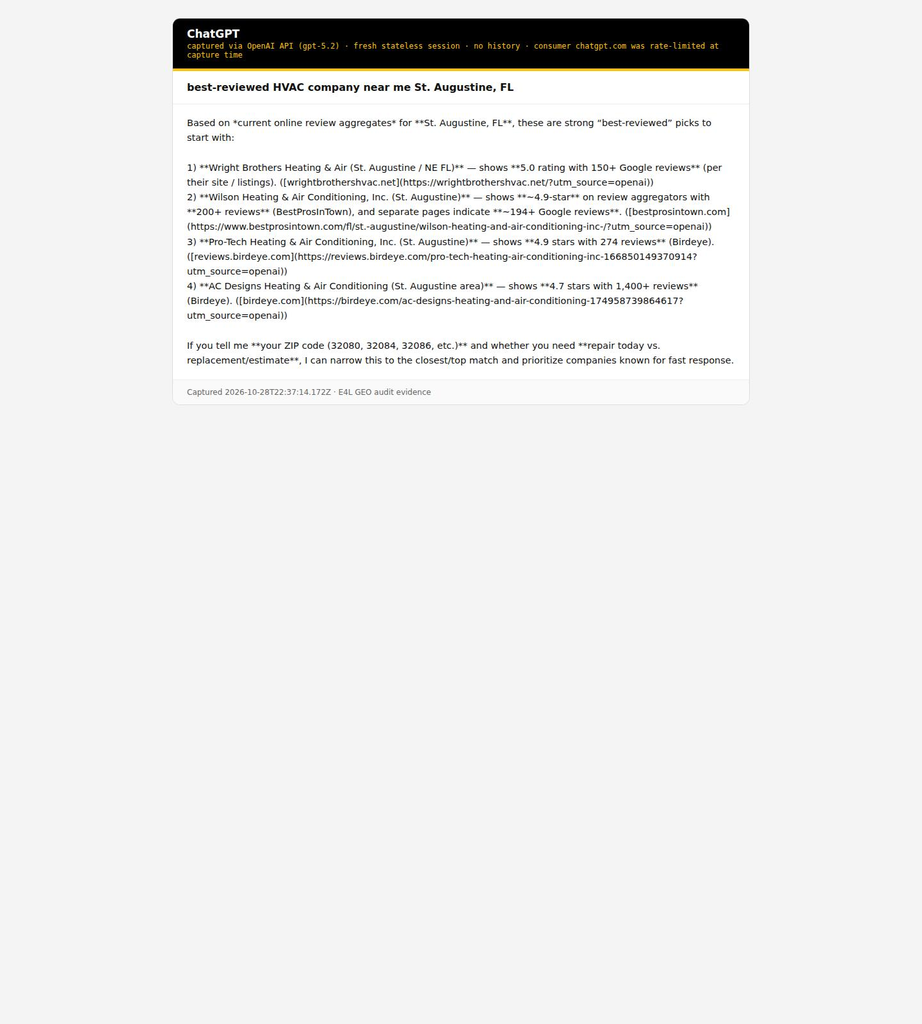

ChatGPT — “best-reviewed HVAC company near me St. Augustine, FL” — others are recommended; Heat Beaters Heating and Air is absent.

## Dashboard line

**AI VISIBILITY — October 2026. Baseline: named in 2/28 AI answers. This month: named in 2/28. Screenshots attached. Next: re-test Perplexity once its limit resets.**